# HW2

Tümay Kır

12/11/2020

# 1 Dimensionality Reduction for Time Series Data

Reading the data.

```r
x_data <- read_excel("C:/Users/tumay/Desktop/X_TRAIN.xlsx",col_names = FALSE)
y_data <- read_excel("C:/Users/tumay/Desktop/Y_TRAIN.xlsx",col_names = FALSE)
z_data <- read_excel("C:/Users/tumay/Desktop/Z_TRAIN.xlsx",col_names = FALSE)

colnames(x_data)[1]<-"class"
colnames(x_data)[2:316]<-c(1:315)
colnames(y_data)[1]<-"class"
colnames(y_data)[2:316]<-c(1:315)
colnames(z_data)[1]<-"class"
colnames(z_data)[2:316]<-c(1:315)
```

Data preparation for all the tasks. The long version of the data is created. Also, the column names of the data frame are arranged. The long format data frame is obtained as required.

```r
x_pivot<-x_data%>%pivot_longer(cols=-class,names_to="time_index")
colnames(x_pivot)[3]<-"X"

y_pivot<-y_data%>%pivot_longer(cols=-class,names_to="time_index")
colnames(y_pivot)[3]<-"Y"

z_pivot<-z_data%>%pivot_longer(cols=-class,names_to="time_index")
colnames(z_pivot)[3]<-"Z"

all_data_long<-cbind(x_pivot,y_pivot$Y)
all_data_long<-cbind(all_data_long,z_pivot$Z)
colnames(all_data_long)[4]<-"Y"
colnames(all_data_long)[5]<-"Z"


all_data_long<-all_data_long %>% relocate(class, .after = last_col())
head(all_data_long)
```

```
##   time_index          X         Y         Z class
## 1          1 -0.3042432 -2.119396 -1.528965     6
## 2          2 -0.3042432 -2.119396 -1.528965     6
## 3          3 -0.3042432 -2.119396 -1.528965     6
## 4          4 -0.3042432 -2.119396 -1.528965     6
## 5          5 -0.3042432 -2.119396 -1.528965     6
## 6          6 -0.3042432 -2.119396 -1.528965     6
```

Then, the cumulative sums are calculated to make comparison between the initial (acceleration) and final (velocity) forms. By using the velocity data, the weight of the variables are plotted and printed.

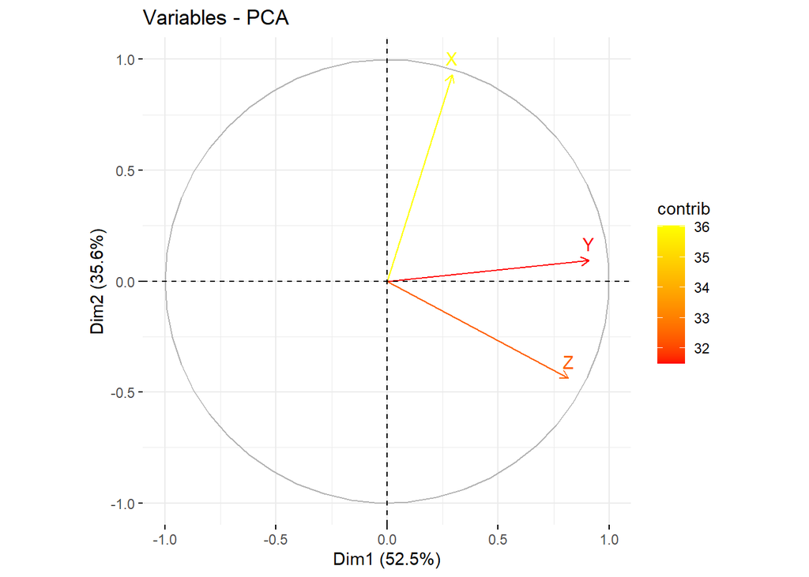

```r
data_cumul<-all_data_long
data_cumul$X<-cumsum(data_cumul$X)
data_cumul$Y<-cumsum(data_cumul$Y)
data_cumul$Z<-cumsum(data_cumul$Z)


data_cumul_pca<-PCA(data_cumul[,2:4])
fviz_pca_var(data_cumul_pca,col.var="contrib", gradient.cols=c("#FF0000","#FFFF00"))
```

```r
summary(data_cumul_pca)
```

```
##
## Call:
## PCA(X = data_cumul[, 2:4])
##
##
## Eigenvalues
##                        Dim.1   Dim.2   Dim.3
## Variance               1.575   1.067   0.358
## % of var.             52.492  35.568  11.940
## Cumulative % of var.  52.492  88.060 100.000
##
## Individuals (the 10 first)
##        Dist    Dim.1    ctr   cos2    Dim.2    ctr   cos2    Dim.3    ctr
## 1  |  0.110 | -0.026  0.000  0.054 | -0.087  0.000  0.629 | -0.062  0.000
## 2  |  0.122 | -0.066  0.000  0.291 | -0.084  0.000  0.478 | -0.059  0.000
## 3  |  0.144 | -0.106  0.000  0.539 | -0.081  0.000  0.315 | -0.055  0.000
## 4  |  0.173 | -0.146  0.000  0.710 | -0.078  0.000  0.201 | -0.051  0.000
## 5  |  0.206 | -0.186  0.000  0.815 | -0.074  0.000  0.131 | -0.048  0.000
## 6  |  0.241 | -0.226  0.000  0.879 | -0.071  0.000  0.087 | -0.044  0.000
## 7  |  0.278 | -0.266  0.000  0.918 | -0.068  0.000  0.060 | -0.041  0.000
## 8  |  0.315 | -0.306  0.000  0.944 | -0.065  0.000  0.042 | -0.037  0.000
## 9  |  0.353 | -0.346  0.000  0.961 | -0.061  0.000  0.030 | -0.034  0.000
## 10 |  0.392 | -0.386  0.000  0.972 | -0.058  0.000  0.022 | -0.030  0.000
##      cos2
## 1   0.317 |
## 2   0.231 |
## 3   0.146 |
## 4   0.088 |
## 5   0.054 |
## 6   0.034 |
## 7   0.022 |
## 8   0.014 |
## 9   0.009 |
## 10  0.006 |
##
## Variables
##       Dim.1    ctr   cos2    Dim.2    ctr   cos2    Dim.3    ctr   cos2
## X  |  0.292  5.409  0.085 |  0.931 81.258  0.867 |  0.219 13.333  0.048 |
## Y  |  0.907 52.275  0.823 |  0.094  0.826  0.009 | -0.410 46.900  0.168 |
## Z  |  0.816 42.316  0.666 | -0.437 17.917  0.191 |  0.377 39.767  0.142 |
```

```r
print(data_cumul_pca)
```

```
## **Results for the Principal Component Analysis (PCA)**
## The analysis was performed on 282240 individuals, described by 3 variables
## *The results are available in the following objects:
##
##    name               description
## 1  "$eig"             "eigenvalues"
## 2  "$var"             "results for the variables"
## 3  "$var$coord"       "coord. for the variables"
## 4  "$var$cor"         "correlations variables - dimensions"
## 5  "$var$cos2"        "cos2 for the variables"
## 6  "$var$contrib"     "contributions of the variables"
## 7  "$ind"             "results for the individuals"
## 8  "$ind$coord"       "coord. for the individuals"
## 9  "$ind$cos2"        "cos2 for the individuals"
## 10 "$ind$contrib"     "contributions of the individuals"
## 11 "$call"            "summary statistics"
## 12 "$call$centre"     "mean of the variables"
## 13 "$call$ecart.type" "standard error of the variables"
## 14 "$call$row.w"      "weights for the individuals"
## 15 "$call$col.w"      "weights for the variables"
```

Conribution of the variables are examined.

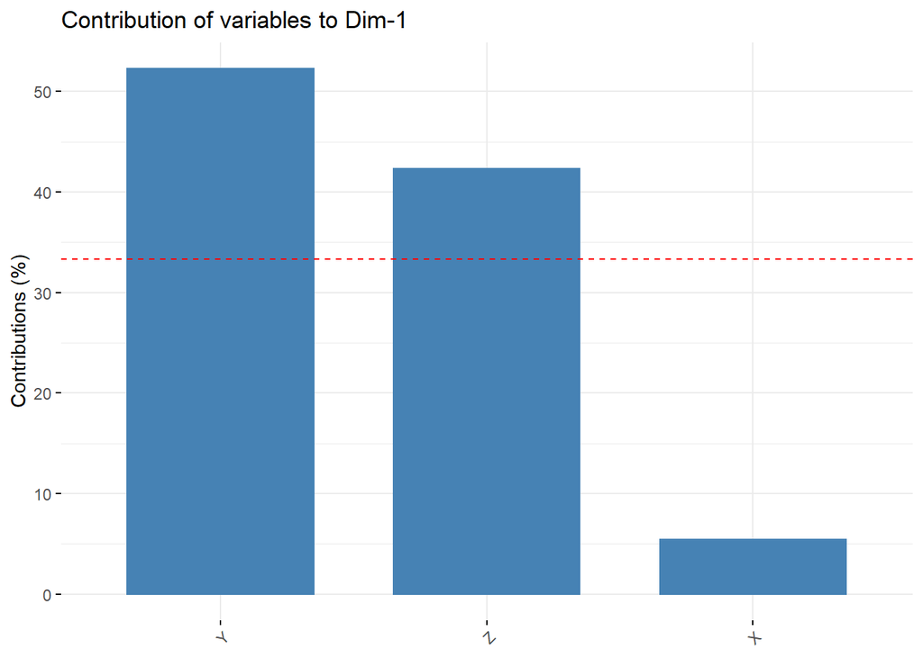

```r
fviz_contrib(data_cumul_pca, choice="var")
```

## 1.1 Task a

### 1.1.1 Class1

First of all, the acceleration data (without cumsum()) is plotted with scatterplot3d function. After that, the cumulative velocity data is plotted 3D.

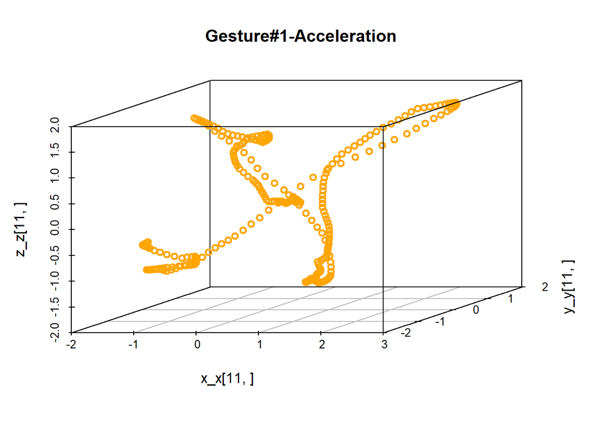

```r
x_x<-as.matrix(x_data[,-1])
y_y<-as.matrix(y_data[,-1])
z_z<-as.matrix(z_data[,-1])

scatterplot3d(x = x_x[11,], y = y_y[11,], z = z_z[11,],color="orange", lwd=2, main = "Gesture#1-Acceleration")
```

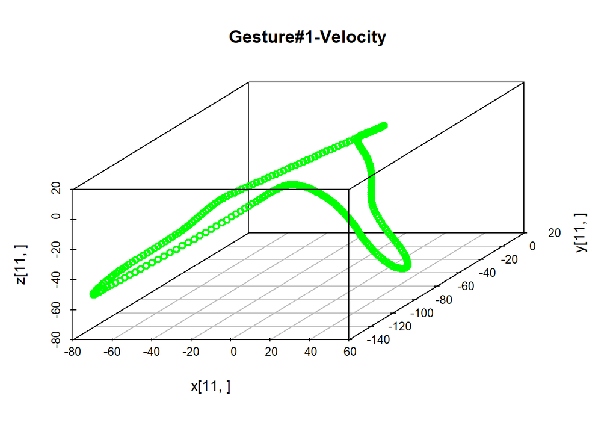

```r
x<-t(apply(x_data[,-1], 1, cumsum))
y<-t(apply(y_data[,-1], 1, cumsum))
z<-t(apply(z_data[,-1], 1, cumsum))


scatterplot3d(x = x[11,], y = y[11,], z = z[11,],color="green", lwd=2, main = "Gesture#1-Velocity")
```

### 1.1.2 Class2

Acceleration data is plotted.

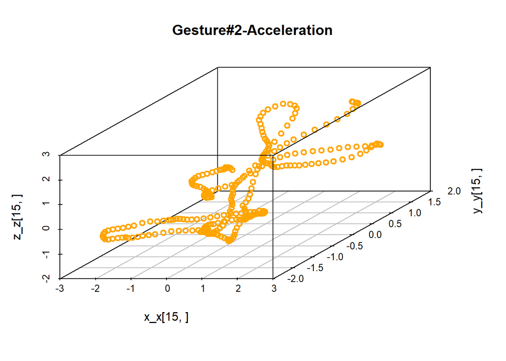

```r
scatterplot3d(x = x_x[15,], y = y_y[15,], z = z_z[15,],color="orange", lwd=2, main = "Gesture#2-Acceleration")
```

Velocity data is plotted.

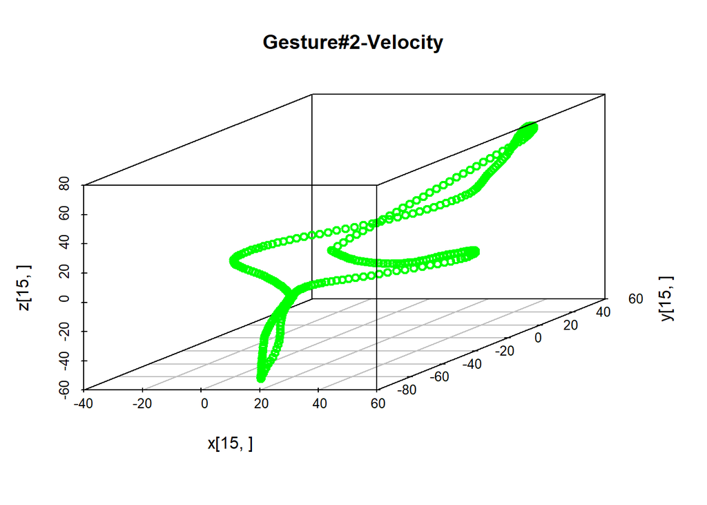

```r
scatterplot3d(x = x[15,], y = y[15,], z = z[15,],color="green", lwd=2, main = "Gesture#2-Velocity")
```

### 1.1.3 Class3

Acceleration data is plotted.

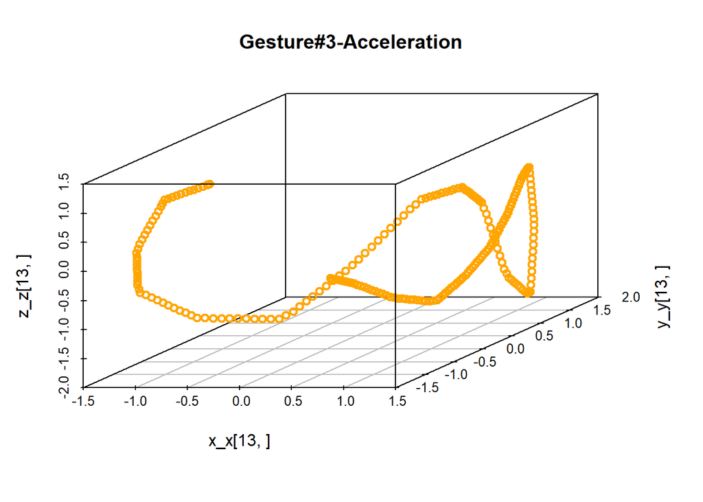

```r
scatterplot3d(x = x_x[13,], y = y_y[13,], z = z_z[13,],color="orange", lwd=2, main = "Gesture#3-Acceleration")
```

Velocity data is plotted.

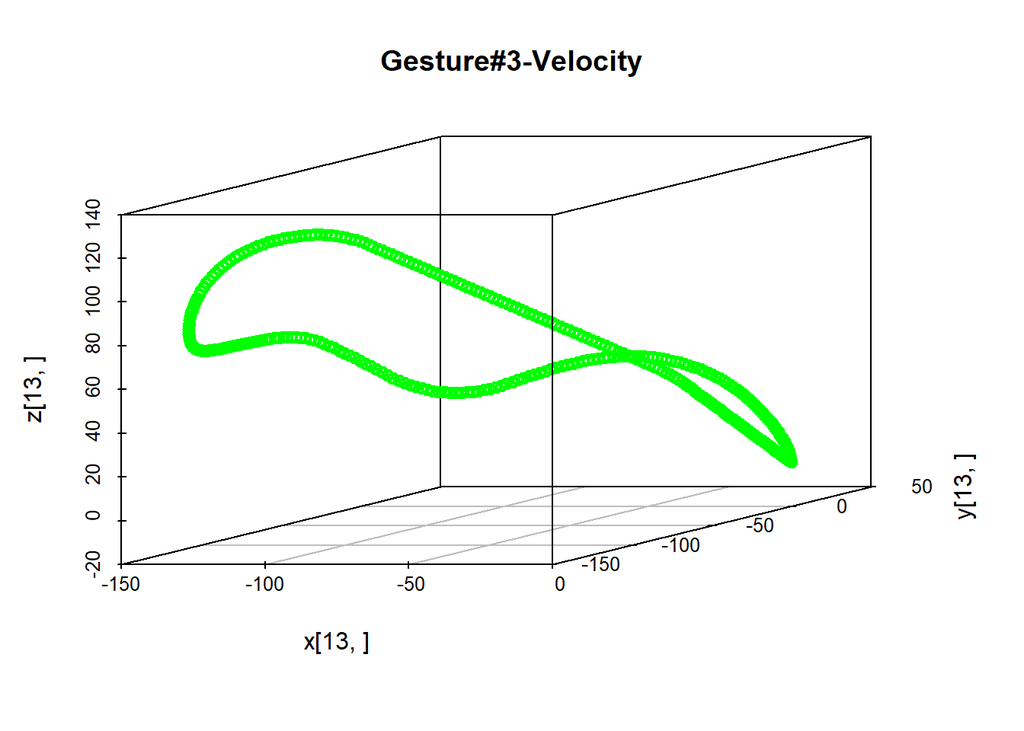

```r
scatterplot3d(x = x[13,], y = y[13,], z = z[13,],color="green", lwd=2, main = "Gesture#3-Velocity")
```

### 1.1.4 Class4

Acceleration data is plotted.

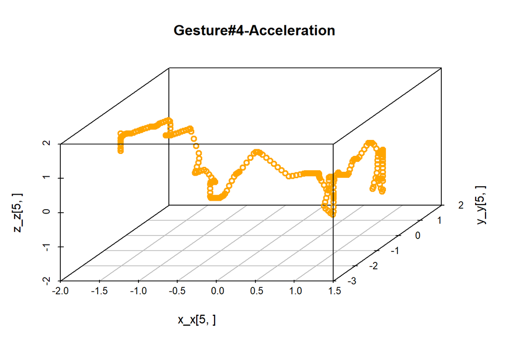

```r
scatterplot3d(x = x_x[5,], y = y_y[5,], z = z_z[5,],color="orange", lwd=2, main = "Gesture#4-Acceleration")
```

Velocity data is plotted.

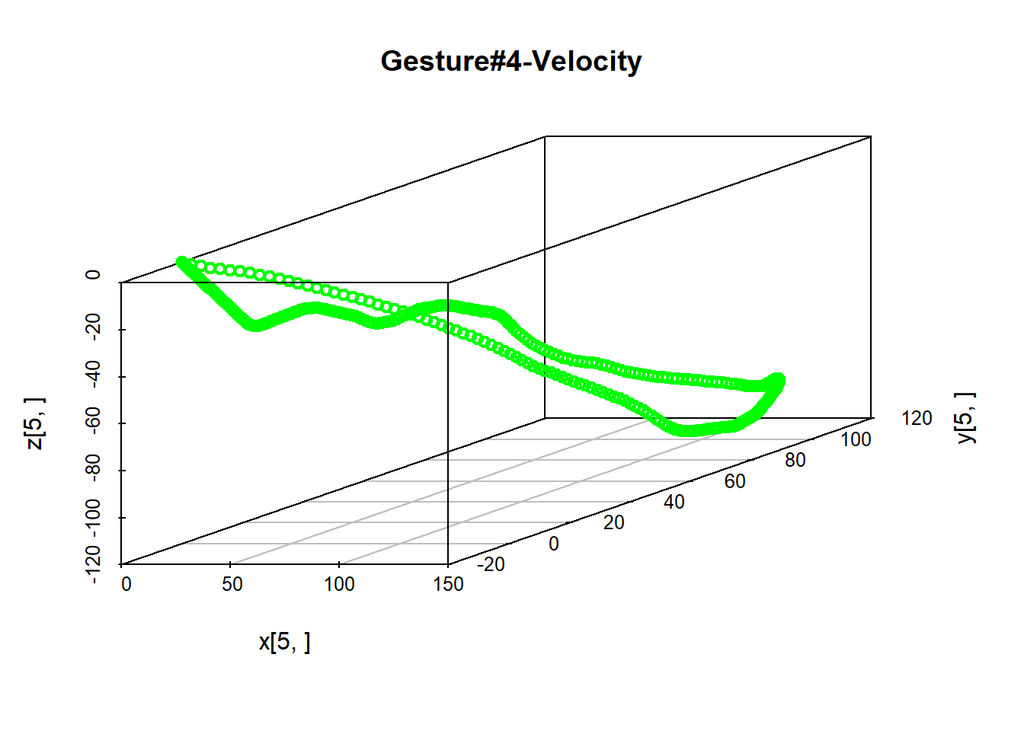

```r
scatterplot3d(x = x[5,], y = y[5,], z = z[5,],color="green", lwd=2, main = "Gesture#4-Velocity")
```

### 1.1.5 Class5

Acceleration data is plotted.

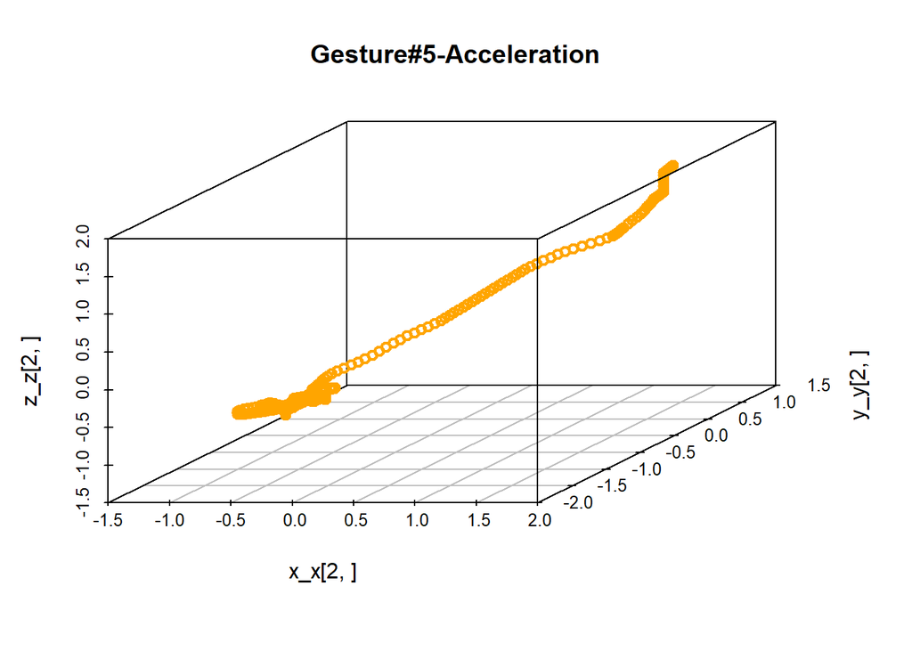

```r
scatterplot3d(x = x_x[2,], y = y_y[2,], z = z_z[2,],color="orange", lwd=2, main = "Gesture#5-Acceleration")
```

Velocity data is plotted.

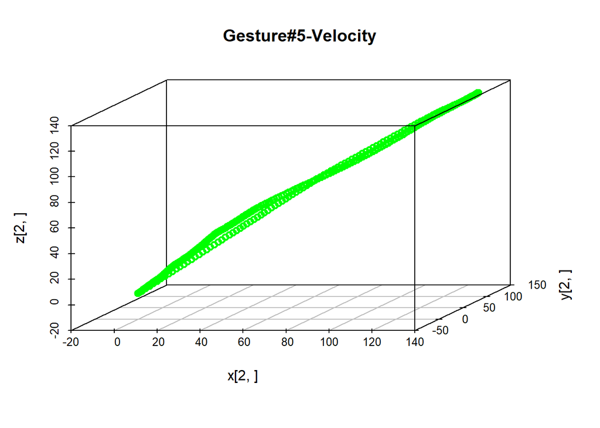

```r
scatterplot3d(x = x[2,], y = y[2,], z = z[2,],color="green", lwd=2, main = "Gesture#5-Velocity")
```

### 1.1.6 Class6

Acceleration data is plotted.

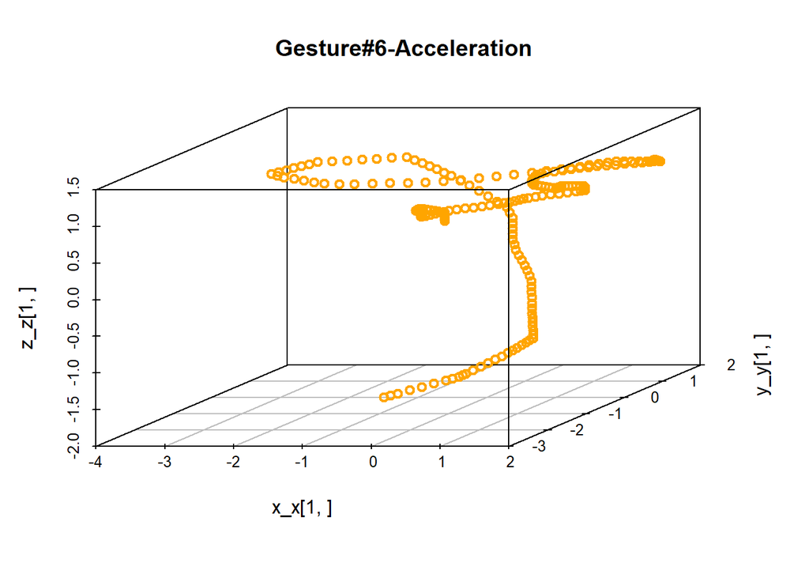

```r
scatterplot3d(x = x_x[1,], y = y_y[1,], z = z_z[1,],color="orange", lwd=2, main = "Gesture#6-Acceleration")
```

Velocity data is plotted.

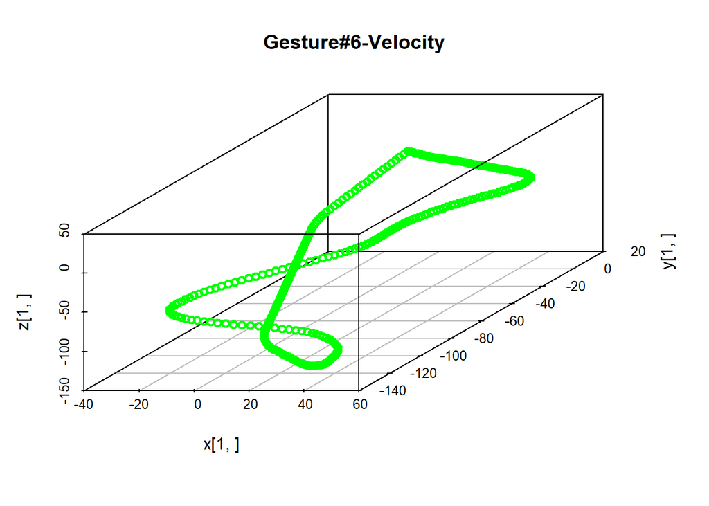

```r
scatterplot3d(x = x[1,], y = y[1,], z = z[1,],color="green", lwd=2, main = "Gesture#6-Velocity")
```

### 1.1.7 Class7

Acceleration data is plotted.

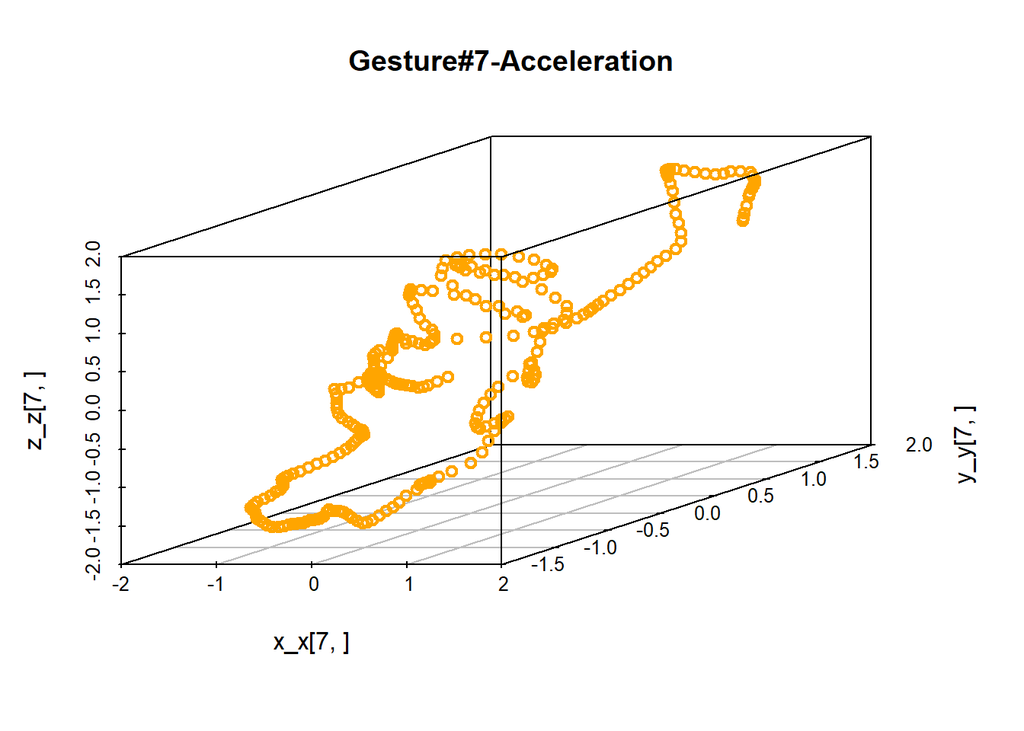

```r
scatterplot3d(x = x_x[7,], y = y_y[7,], z = z_z[7,],color="orange", lwd=2, main = "Gesture#7-Acceleration")
```

Velocity data is plotted.

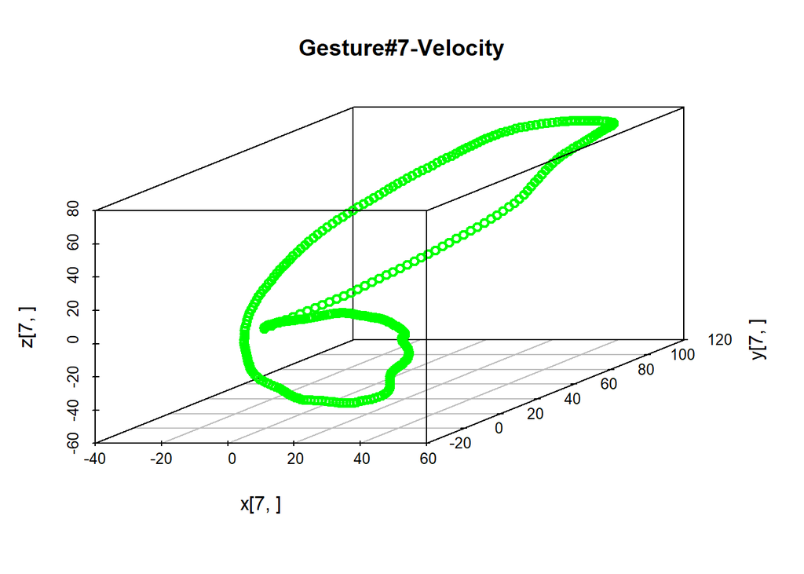

```r
scatterplot3d(x = x[7,], y = y[7,], z = z[7,],color="green", lwd=2, main = "Gesture#7-Velocity")
```

### 1.1.8 Class8

Acceleration data is plotted.

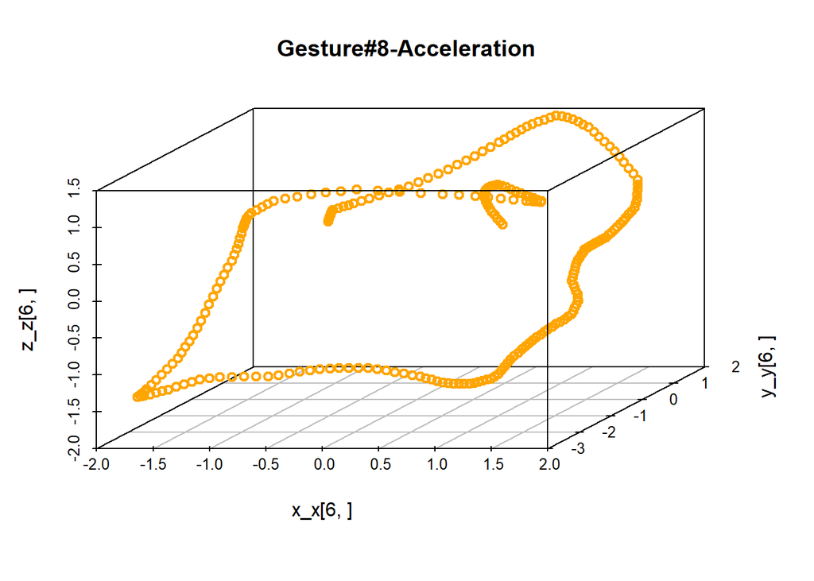

```r
scatterplot3d(x = x_x[6,], y = y_y[6,], z = z_z[6,],color="orange", lwd=2, main = "Gesture#8-Acceleration")
```

Velocity data is plotted.

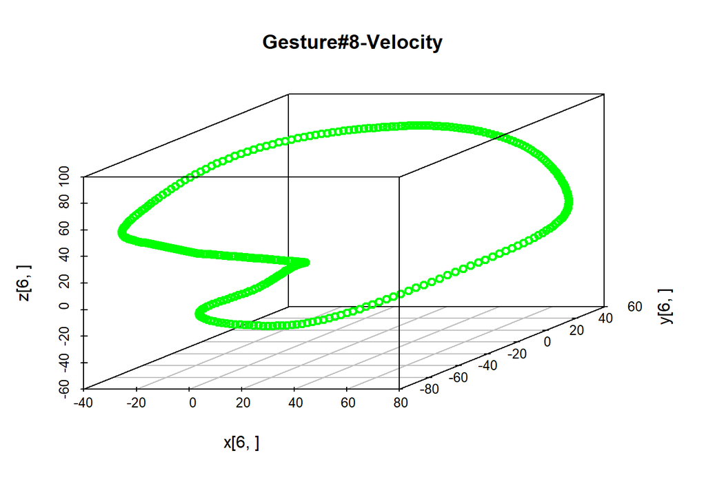

```r
scatterplot3d(x = x[6,], y = y[6,], z = z[6,],color="green", lwd=2, main = "Gesture#8-Velocity")
```

As a conclusion, it can be said that the cumulative version of the data, velocity data, makes much more sense than the acceleration data. So, we can observe the gestures by looking at the velocity scatterplots.

## 1.2 Task b

A function to see the proportions of variances visually.

```r
pcaCharts <- function(x) {
  x.var <- x$sdev ^ 2
  x.pvar <- x.var/sum(x.var)
  print("proportions of variance:")
  print(x.pvar)

  par(mfrow=c(2,2))
  plot(x.pvar,xlab="Principal component", ylab="Proportion of variance explained", ylim=c(0,1), type='b')
  plot(cumsum(x.pvar),xlab="Principal component", ylab="Cumulative Proportion of variance explained", ylim=c(0,1), type='b')
  screeplot(x)
  screeplot(x,type="l")
  par(mfrow=c(1,1))
}
```

From the summary function, it can be seen that the first principal component has the largest proportion of variance, which is %49.06. The proportions of PC2 and PC3 are %34.67 and %16.27, relatively.

```r
data_pca <- prcomp(scale(all_data_long[,2:4]),center = TRUE)
names(data_pca)
```

```
## [1] "sdev"     "rotation" "center"   "scale"    "x"
```

```r
print(data_pca)
```

```
## Standard deviations (1, .., p=3):
## [1] 1.2131714 1.0198583 0.6986445
##
## Rotation (n x k) = (3 x 3):
##         PC1         PC2        PC3
## X 0.4268455 -0.77631140 -0.4638357
## Y 0.7212650 -0.01714887  0.6924469
## Z 0.5455087  0.63011628 -0.5526063
```

```r
summary(data_pca)
```

```
## Importance of components:
##                           PC1    PC2    PC3
## Standard deviation     1.2132 1.0199 0.6986
## Proportion of Variance 0.4906 0.3467 0.1627
## Cumulative Proportion  0.4906 0.8373 1.0000
```

```
## [1] "proportions of variance:"
## [1] 0.4905950 0.3467037 0.1627014
```

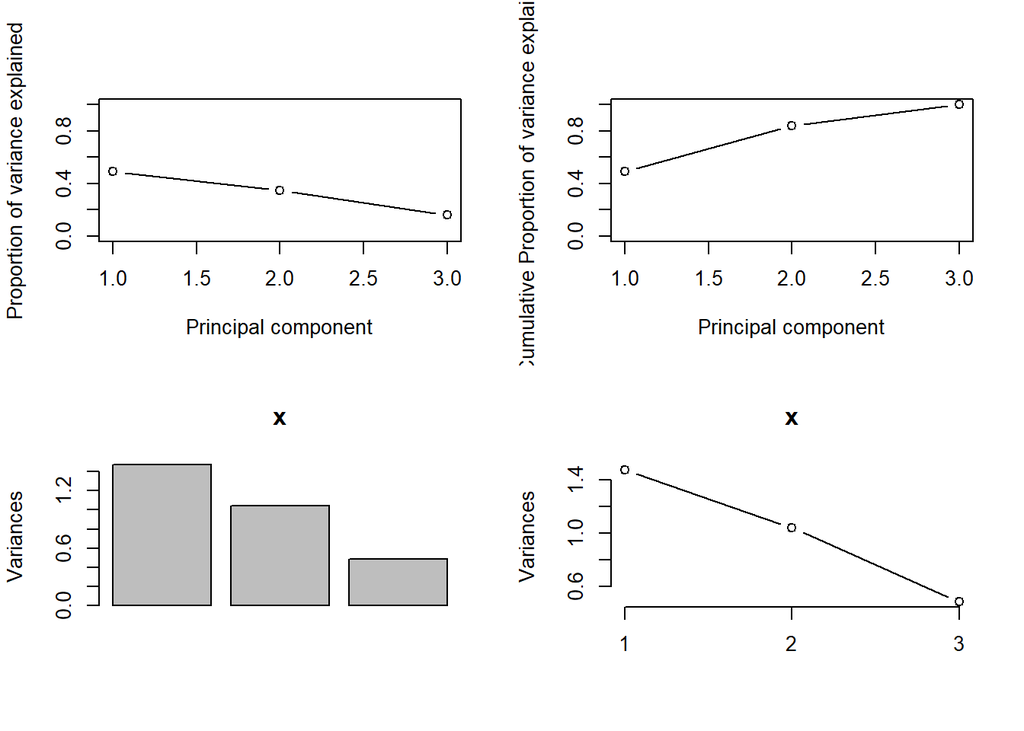

```r
pcaCharts(data_pca)
```

Since the largest weight is on PC1, we choose it to do dimension reduction from 3D to 1D. By calculating the value “reduced”, we can visualize the reduced dimensions as time series in a single plot.

```r
all_data_long<- all_data_long %>% mutate(reduced =0.4268455*X+ 0.7212650*Y+0.5455087*Z)

all_data_long<-all_data_long %>% relocate(class, .after = last_col())

id<-x_data
id<-id%>%mutate(id=seq.int(nrow(id)))
id<-id[,c(ncol(id),1:(ncol(id)-1))]
id<-id%>%pivot_longer(-c(class,id), names_to = "time_index")

all_data_long<-cbind(id$id,all_data_long)
colnames(all_data_long)[1]<-"time_series_id"

all_data_long$time_index<-as.numeric(all_data_long$time_index)
all_data_long<-all_data_long%>%mutate(time_series_id = as_factor(time_series_id))
```

I select two random time series from Class1.

### 1.2.1 Class1

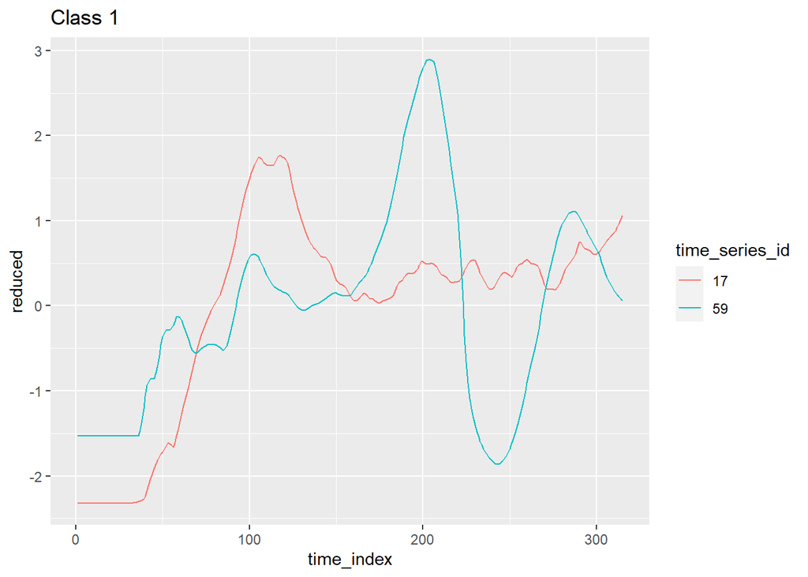

```r
class1 <- all_data_long %>% filter(time_series_id==17 | time_series_id==59)%>%select(time_series_id,time_index,reduced,class)

ggplot(class1) + geom_line(aes(x=time_index, y=reduced, colour=time_series_id))+ ggtitle("Class 1")
```

### 1.2.2 Class2

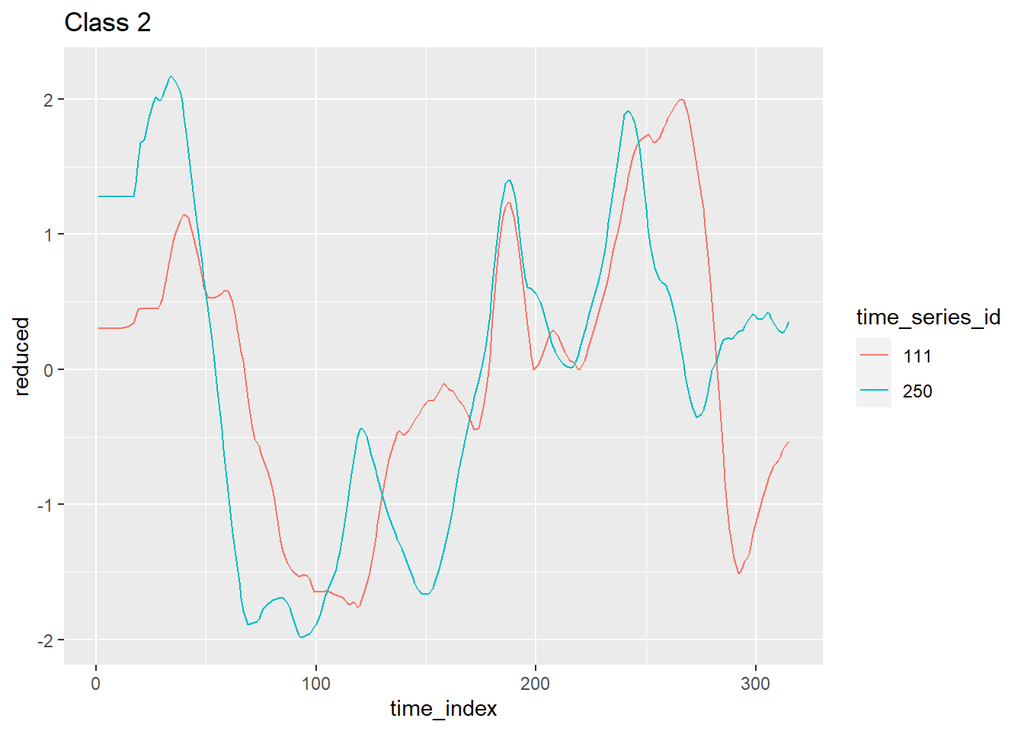

```r
class2 <- all_data_long %>% filter(time_series_id==111 | time_series_id==250)%>%select(time_series_id,time_index,reduced,class)

ggplot(class2) + geom_line(aes(x=time_index, y=reduced, colour=time_series_id))+ ggtitle("Class 2")
```

### 1.2.3 Class3

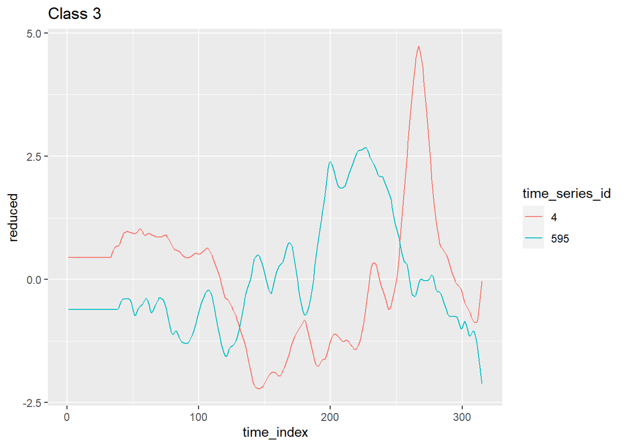

```r
class3 <- all_data_long %>% filter(time_series_id==4 | time_series_id==595)%>%select(time_series_id,time_index,reduced,class)


ggplot(class3) + geom_line(aes(x=time_index, y=reduced, colour=time_series_id)) + ggtitle("Class 3")
```

### 1.2.4 Class4

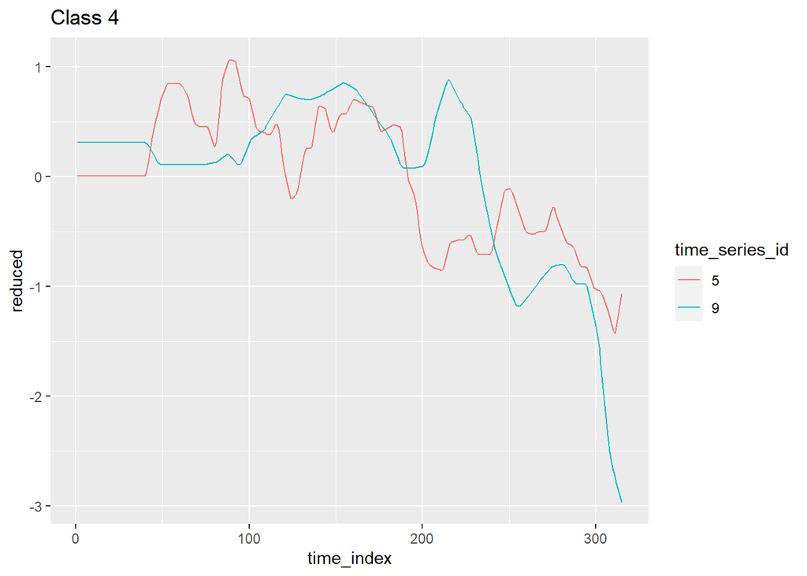

```r
class4 <- all_data_long %>% filter(time_series_id==5 | time_series_id==9)%>%select(time_series_id,time_index,reduced,class)


ggplot(class4) + geom_line(aes(x=time_index, y=reduced, colour=time_series_id)) + ggtitle("Class 4")
```

### 1.2.5 Class5

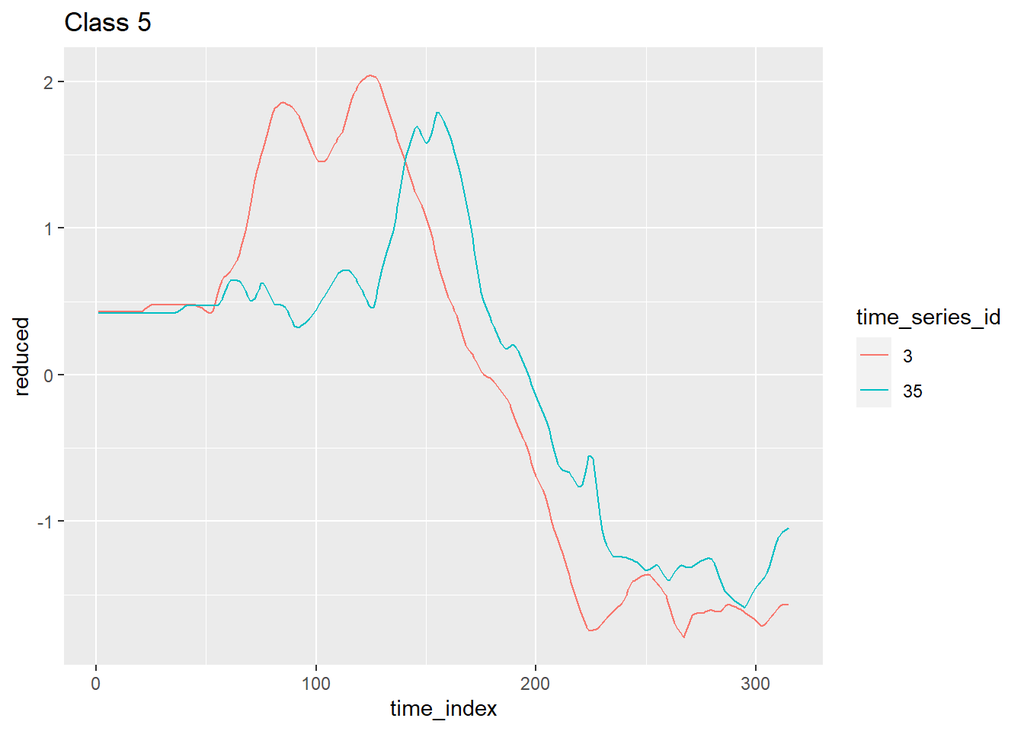

```r
class5 <- all_data_long %>% filter(time_series_id==3 | time_series_id==35)%>%select(time_series_id,time_index,reduced,class)


ggplot(class5) + geom_line(aes(x=time_index, y=reduced, colour=time_series_id))+ ggtitle("Class 5")
```

### 1.2.6 Class6

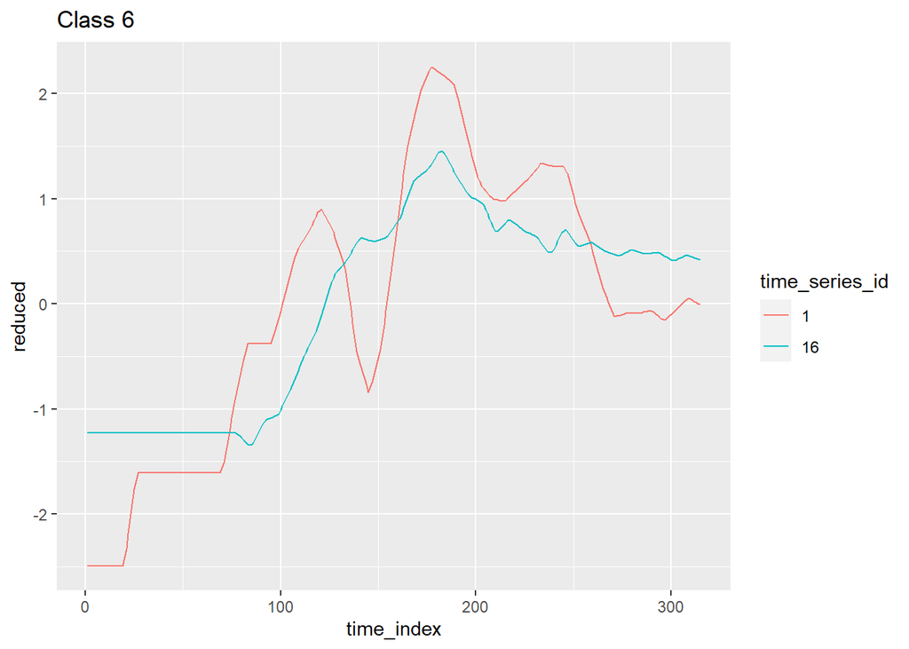

```r
class6 <- all_data_long %>% filter(time_series_id==1 | time_series_id==16)%>%select(time_series_id,time_index,reduced,class)


ggplot(class6) + geom_line(aes(x=time_index, y=reduced, colour=time_series_id))+ ggtitle("Class 6")
```

### 1.2.7 Class7

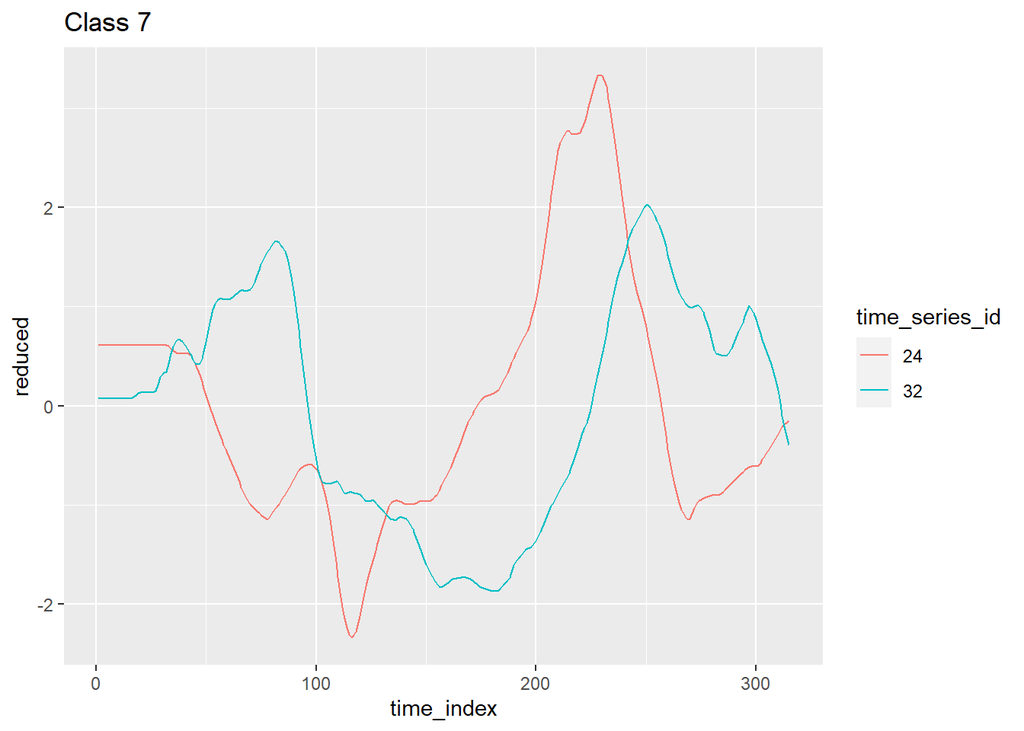

```r
class7 <- all_data_long %>% filter(time_series_id==24 | time_series_id==32)%>%select(time_series_id,time_index,reduced,class)


ggplot(class7) + geom_line(aes(x=time_index, y=reduced, colour=time_series_id)) + ggtitle("Class 7")
```

### 1.2.8 Class8

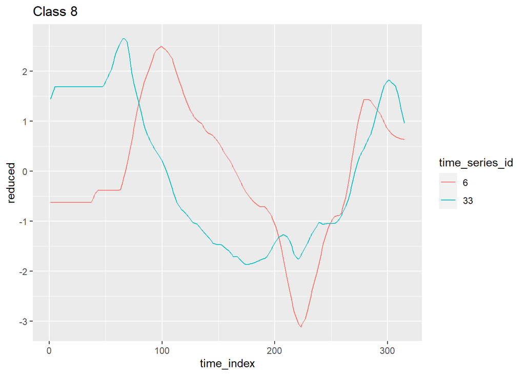

```r
class8 <- all_data_long %>% filter(time_series_id==6 | time_series_id==33)%>%select(time_series_id,time_index,reduced,class)


ggplot(class8) + geom_line(aes(x=time_index, y=reduced, colour=time_series_id))+ ggtitle("Class 8")
```

## 1.3 Task c

This time, PCA is applied on the data from each gesture one by one. The data is filtered from each gesture(class) and PCA is applied for each class, eight times totally.

```r
class1<-all_data_long%>%filter(class=="1")
pca_1 <- prcomp(scale(class1[,3:5]),center=TRUE)
summary(pca_1)
```

```
## Importance of components:
##                           PC1    PC2    PC3
## Standard deviation     1.1780 0.9846 0.8019
## Proportion of Variance 0.4625 0.3231 0.2143
## Cumulative Proportion  0.4625 0.7857 1.0000
```

```r
print(pca_1)
```

```
## Standard deviations (1, .., p=3):
## [1] 1.1779640 0.9845807 0.8018738
##
## Rotation (n x k) = (3 x 3):
##         PC1        PC2        PC3
## X 0.3567943  0.8962945 -0.2633513
## Y 0.6911427 -0.0636012  0.7199143
## Z 0.6285058 -0.4388747 -0.6421600
```

```r
class2<-all_data_long%>%filter(class=="2")
pca_2 <- prcomp(scale(class2[,3:5]),center=TRUE)
summary(pca_2)
```

```
## Importance of components:
##                           PC1    PC2    PC3
## Standard deviation     1.2400 0.9683 0.7244
## Proportion of Variance 0.5125 0.3125 0.1749
## Cumulative Proportion  0.5125 0.8251 1.0000
```

```r
print(pca_2)
```

```
## Standard deviations (1, .., p=3):
## [1] 1.2400176 0.9682706 0.7244366
##
## Rotation (n x k) = (3 x 3):
##          PC1        PC2        PC3
## X -0.4554176 -0.8014690 -0.3876110
## Y -0.6845547  0.0368908  0.7280274
## Z -0.5691921  0.5968974 -0.5654501
```

```r
class3<-all_data_long%>%filter(class=="3")
pca_3 <- prcomp(scale(class3[,3:5]),center=TRUE)
summary(pca_3)
```

```
## Importance of components:
##                           PC1    PC2    PC3
## Standard deviation     1.2737 0.9475 0.6928
## Proportion of Variance 0.5407 0.2993 0.1600
## Cumulative Proportion  0.5407 0.8400 1.0000
```

```r
print(pca_3)
```

```
## Standard deviations (1, .., p=3):
## [1] 1.2736687 0.9475424 0.6927707
##
## Rotation (n x k) = (3 x 3):
##          PC1         PC2        PC3
## X -0.6747233 0.009098704 -0.7380147
## Y -0.5306881 0.688955376  0.4936706
## Z  0.5129510 0.724746648 -0.4600257
```

```r
class4<-all_data_long%>%filter(class=="4")
pca_4 <- prcomp(scale(class4[,3:5]),center=TRUE)
summary(pca_4)
```

```
## Importance of components:
##                           PC1    PC2    PC3
## Standard deviation     1.2847 0.9606 0.6534
## Proportion of Variance 0.5501 0.3076 0.1423
## Cumulative Proportion  0.5501 0.8577 1.0000
```

```r
print(pca_4)
```

```
## Standard deviations (1, .., p=3):
## [1] 1.2846735 0.9605566 0.6534102
##
## Rotation (n x k) = (3 x 3):
##          PC1       PC2        PC3
## X -0.6806323 0.1125840 -0.7239230
## Y -0.6342065 0.4041375  0.6591320
## Z  0.3667721 0.9077432 -0.2036675
```

```r
class5<-all_data_long%>%filter(class=="5")
pca_5 <- prcomp(scale(class5[,3:5]),center=TRUE)
summary(pca_5)
```

```
## Importance of components:
##                           PC1    PC2     PC3
## Standard deviation     1.3934 0.9077 0.48425
## Proportion of Variance 0.6472 0.2746 0.07817
## Cumulative Proportion  0.6472 0.9218 1.00000
```

```r
print(pca_5)
```

```
## Standard deviations (1, .., p=3):
## [1] 1.3934383 0.9076507 0.4842520
##
## Rotation (n x k) = (3 x 3):
##          PC1        PC2         PC3
## X -0.3988772 -0.9154472  0.05341656
## Y -0.6425900  0.3205950  0.69591444
## Z -0.6541980  0.2432595 -0.71613529
```

```r
class6<-all_data_long%>%filter(class=="6")
pca_6 <- prcomp(scale(class6[,3:5]),center=TRUE)
summary(pca_6)
```

```
## Importance of components:
##                           PC1    PC2     PC3
## Standard deviation     1.3098 0.9942 0.54420
## Proportion of Variance 0.5718 0.3295 0.09872
## Cumulative Proportion  0.5718 0.9013 1.00000
```

```r
print(pca_6)
```

```
## Standard deviations (1, .., p=3):
## [1] 1.3097601 0.9941695 0.5442016
##
## Rotation (n x k) = (3 x 3):
##          PC1         PC2        PC3
## X  0.2060269 -0.96424253  0.1667011
## Y -0.6797230 -0.26356876 -0.6844765
## Z -0.7039386 -0.02771001  0.7097201
```

```r
class7<-all_data_long%>%filter(class=="7")
pca_7 <- prcomp(scale(class7[,3:5]),center=TRUE)
summary(pca_7)
```

```
## Importance of components:
##                           PC1    PC2    PC3
## Standard deviation     1.2480 1.0144 0.6429
## Proportion of Variance 0.5192 0.3430 0.1378
## Cumulative Proportion  0.5192 0.8622 1.0000
```

```r
print(pca_7)
```

```
## Standard deviations (1, .., p=3):
## [1] 1.2480424 1.0144419 0.6428823
##
## Rotation (n x k) = (3 x 3):
##          PC1         PC2        PC3
## X -0.2290300 -0.92481420 -0.3037498
## Y -0.7150258 -0.05190498  0.6971685
## Z -0.6605175  0.37686147 -0.6493782
```

```r
class8<-all_data_long%>%filter(class=="8")
pca_8 <- prcomp(scale(class8[,3:5]),center=TRUE)
summary(pca_8)
```

```
## Importance of components:
##                           PC1    PC2     PC3
## Standard deviation     1.3566 0.9676 0.47278
## Proportion of Variance 0.6134 0.3121 0.07451
## Cumulative Proportion  0.6134 0.9255 1.00000
```

```r
print(pca_8)
```

```
## Standard deviations (1, .., p=3):
## [1] 1.3565694 0.9675745 0.4727781
##
## Rotation (n x k) = (3 x 3):
##         PC1         PC2        PC3
## X 0.5744344 -0.58391123  0.5736487
## Y 0.6927923 -0.02643827 -0.7206524
## Z 0.4359633  0.81138690  0.3893422
```

To make comparison among all the classes, I merged all PC1 components into a matrix. I think, using prcomp() instead of princomp() created a slightly different results. It’s very likely that the minus signs result from some functions and point of reference. It doesn’t change the logic and result. It shows the negative correlation between components.

```r
component_matrix<-cbind(pca_1$rotation[,1],pca_2$rotation[,1],pca_3$rotation[,1],pca_4$rotation[,1],pca_5$rotation[,1],pca_6$rotation[,1],pca_7$rotation[,1],pca_8$rotation[,1])
component_matrix
```

```
##        [,1]       [,2]       [,3]       [,4]       [,5]       [,6]       [,7]
## X 0.3567943 -0.4554176 -0.6747233 -0.6806323 -0.3988772  0.2060269 -0.2290300
## Y 0.6911427 -0.6845547 -0.5306881 -0.6342065 -0.6425900 -0.6797230 -0.7150258
## Z 0.6285058 -0.5691921  0.5129510  0.3667721 -0.6541980 -0.7039386 -0.6605175
##        [,8]
## X 0.5744344
## Y 0.6927923
## Z 0.4359633
```

## 1.4 Task d

I created the Euclidean distance matrix and checked if it is symmetric or not.

```r
all_data<-cbind(x_data,y_data[,-1],z_data[,-1])
all_data[,-1]<-scale(all_data[,-1])

dist_matrix = as.matrix(dist(all_data[,-1], method = "euclidean"))
isSymmetric(dist_matrix)
```

```
## [1] TRUE
```

Then, I applied Multi-dimensional scaling to this distance matrix to represent each time series on a 2-dimensional feature space and I visualize the observations using the reduced features and color-code the points with the class information.

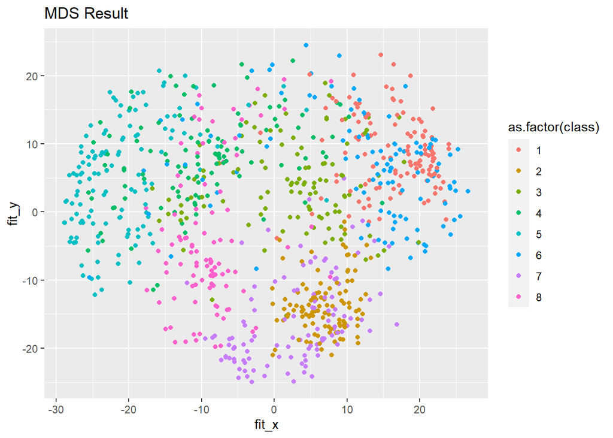

```r
fit <- cmdscale(dist_matrix,eig=TRUE, k=2)
fit_x<-fit$points[,1]
fit_y<-fit$points[,2]

fit_w_class<-data.table(cbind(fit_x,fit_y,all_data$class))
colnames(fit_w_class)[3]<-"class"

ggplot(fit_w_class,aes(x=fit_x,y=fit_y,color=as.factor(class)))+geom_point()+ ggtitle("MDS Result")
```

While some classes are distinguishable, some are not. From the plot, Class1 and Class6 look like indistinguishable.